# EasyVisa_Full_Code_Notebook

## Model Building

### Model Evaluation Criterion

- Choose the primary metric to evaluate the model on
- Elaborate on the rationale behind choosing the metric

First, let's create functions to calculate different metrics and confusion matrix so that we don't have to use the same code repeatedly for each model.

- The `model_performance_classification_sklearn` function will be used to check the model performance of models.
- The `confusion_matrix_sklearn` function will be used to plot the confusion matrix.

```python
#Creating the functions to prduce different metrics for our models.
def model_performance_classification_sklearn(model, X_train, y_train, X_test, y_test, flag=True):

  #Defining an empty list to store train and test results
  metrics_list = []

  #Predicting on train and tests.
  pred_train = model.predict(X_train)
  pred_test = model.predict(X_test)

  #Accuracy of the model
  train_acc= model.score(X_train, y_train)
  test_acc = model.score(X_test, y_test)

  #Recall of the model
  train_recall= metrics.recall_score(y_train, pred_train, pos_label= 1)
  test_recall = metrics.recall_score(y_test, pred_test, pos_label= 1)

  #Precision of the model
  train_precision= metrics.precision_score(y_train, pred_train, pos_label= 1)
  test_precision = metrics.precision_score(y_test, pred_test, pos_label= 1)

  #F1 score of the model
  train_f1= metrics.f1_score(y_train, pred_train, pos_label= 1)
  test_f1 = metrics.f1_score(y_test, pred_test, pos_label= 1)

  metrics_list.extend((train_acc, test_acc, train_recall, test_recall, train_precision, test_precision, train_f1, test_f1))

  #If the flag is set to true then only the following print statements will be displayed.
  if flag == True:
    print('Accuracy on training set:' ,model.score(X_train, y_train))
    print('Accuracy on test set:' ,model.score(X_test, y_test))
    print('Recall on training set:' ,metrics.recall_score(y_train, pred_train, pos_label= 1))
    print('Recall on test set:' ,metrics.recall_score(y_test, pred_test, pos_label= 1))
    print('Precision on training set:' ,metrics.precision_score(y_train, pred_train, pos_label= 1))
    print('Precision on test set:' ,metrics.precision_score(y_test, pred_test, pos_label= 1))
    print('F1 score on training set:' ,metrics.f1_score(y_train, pred_train, pos_label= 1))
    print('F1 score on test set:' ,metrics.f1_score(y_test, pred_test, pos_label= 1))

    #Return the test and train scores.
    return metrics_list
```

```python
#Creating the function for the confusion matrix for our models.-
def confusion_matrix_sklearn(model, predictors, target):
    """
    To plot the confusion_matrix with percentages

    model: classifier
    predictors: independent variables
    target: dependent variable
    """
    y_pred = model.predict(predictors)
    cm = confusion_matrix(target, y_pred)
    labels = np.asarray(
        [
            ["{0:0.0f}".format(item) + "\n{0:.2%}".format(item / cm.flatten().sum())]
            for item in cm.flatten()
        ]
    ).reshape(2, 2)

    plt.figure(figsize=(6, 4))
    sns.heatmap(cm, annot=labels, fmt="")
    plt.ylabel("True label")
    plt.xlabel("Predicted label")
    plt.title("Confusion Matrix")
```

#### Defining scorer to be used for cross-validation and hyperparameter tuning

```python
#Defining scorer bering used for corss validation and hyperparameter tuning.
from sklearn.metrics import make_scorer, f1_score
f1_scorer = make_scorer(f1_score, pos_label= 'Certified')
```

```python
#I am choosing f1 scorer to determine eligibilty becuase it balances both precision and recall, which is important becuase flase positives and false negatives have an impact on certification.
```

**We are now done with pre-processing and evaluation criterion, so let's start building the model.**

### Model building with Original data

```python
models = [] #Empty list to store

#Appending models
models.append(('Bagging', BaggingClassifier(random_state=42)))
models.append(('AdaBoost', AdaBoostClassifier(random_state=42)))
models.append(('Random Forest', RandomForestClassifier(random_state=42)))
models.append(('Gradient Boosting', GradientBoostingClassifier(random_state=42)))
models.append(('dtree', DecisionTreeClassifier(random_state=42)))

results1 = [] #Empty list to store results.
names1 = []  #Empty list to store the names of the models.

#Loop through all of the models.
for name, model in models:
  kfold = StratifiedKFold(n_splits=5, shuffle=True, random_state=42)
  cv_results = cross_val_score(model, X_train, y_train, cv=kfold, scoring=f1_scorer)
  results1.append(cv_results)
  names1.append(name)
  print(f'{name}: {cv_results.mean():.4f}')

print('\n' 'Vaildation Performance:' '\n')

for name, model in models:
  model.fit(X_train, y_train)
  print(f'{name}: {model.score(X_val, y_val):.4f}')
```

```
Bagging: 0.8188
AdaBoost: 0.8186
Random Forest: 0.8204
Gradient Boosting: 0.8238
dtree: 0.8221

Vaildation Performance:

Bagging: 0.7407
AdaBoost: 0.7424
Random Forest: 0.7431
Gradient Boosting: 0.7495
dtree: 0.7446
```

```python
#Based on the results Gradient boosting seems to perform the best. But the other models are very close behind with Decision tree close behind.
```

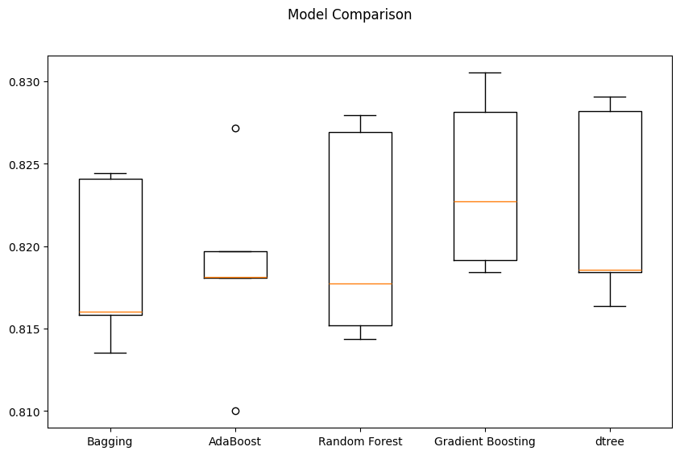

```python
#Created a boxplot to show the differecnes in the models.
fig = plt.figure(figsize=(10, 6))
fig.suptitle('Model Comparison')
ax = fig.add_subplot(111)
plt.boxplot(results1)
ax.set_xticklabels(names1)
plt.show()
```

```python
#Gradient boosting seems to have the best model thus far.
```